# Simple Neuron Models

2025

## The Leaky Integrate and Fire (LIF) Model

\[ \tau_m \frac{d}{dt} v(t) = -(v(t) - v_{rest}) + I(t) \\ \text{if } v(t) > v_{thresh}, \text{then } v(t) \leftarrow v_{reset} \]

## LIF properties

- Linearly adds up inputs until the membrane potential crosses a threshold, at which point a spike is triggered, and the membrane potential is reset.
- Spikes are all-or-none assumed to be identical in size and duration.
- Spikes aren’t actually part of the stimulation. They are just hand drawn in when threshold is crossed.
- There can be something of a refractory period if the reset potential is set to hyperpolarize the membrane potential.
- The amplitude of an input is linearly encoded into the frequency of spiking. This is called **Class 1 excitability**.

## LIF Model Simulation

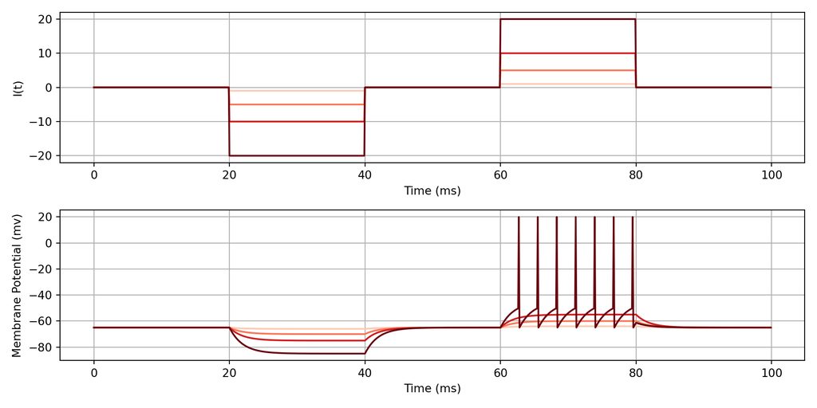

## The Quadratic Integrate and Fire (QIF) Model

\[ \tau_m \frac{d}{dt} v(t) = (v(t) - v_{rest})^2 + I(t) \\ \text{if } v(t) > v_{\text{thresh}}, \text{then } v(t) \leftarrow v_{\text{reset}} \]

**Parameters:**

- \(\tau_m\): Membrane time constant
- \(v_{rest}\): Resting potential
- \(v_{thresh}\): Spike threshold (set arbitrarily high)
- \(c_{reset}\): Reset voltage after spike

## QIF Model Simulation

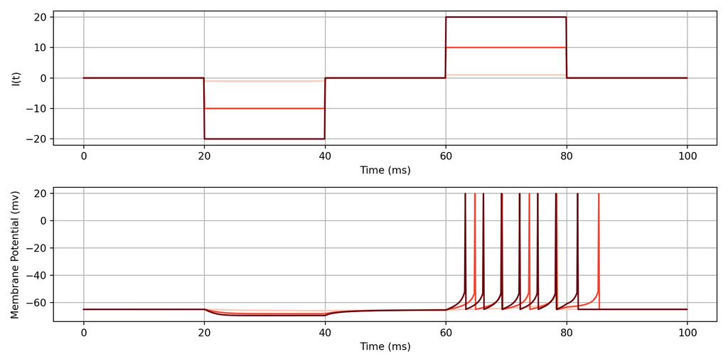

## The Izhikevich (Iz) Model

\[ \frac{dv}{dt} = k(v - v_{\text{rest}})(v - v_{\text{thresh}}) - u + I \]

\[ \frac{du}{dt} = a(bv - u) \]

\[ \text{if } v \geq v_{\text{peak}}, \quad \begin{cases} v \leftarrow c \\\\ u \leftarrow u + d \end{cases} \]

## Iz Parameters

- \(v\): membrane potential
- \(u\): recovery variable
- \(a, b, c, d\): recovery parameters
- \(k\): curvature of the voltage parabola
- \(v_{\text{rest}}\): resting potential
- \(v_{\text{thresh}}\): threshold potential
- \(v_{\text{peak}}\): spike cutoff/reset threshold
- \(I\): input current

## Why the Izhikevich Model?

- It is a phenomenological model — built to reproduce complex firing patterns using minimal equations
- It trades biophysical realism for:
  - A rich repertoire of spiking behaviors
  - Very low computational cost
  - Easy switching between neuron types (just tweak a few parameters)

## Iz Model Simulation tuned to look like QIF

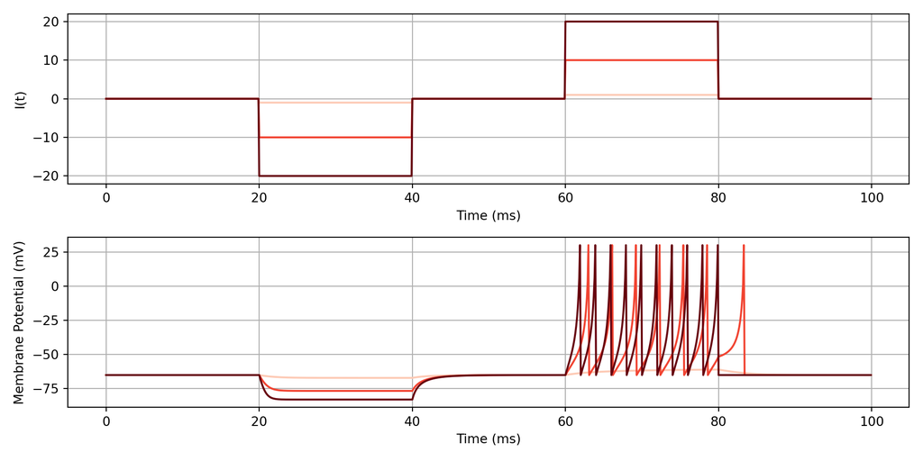

## Simple Model of the Thalamus

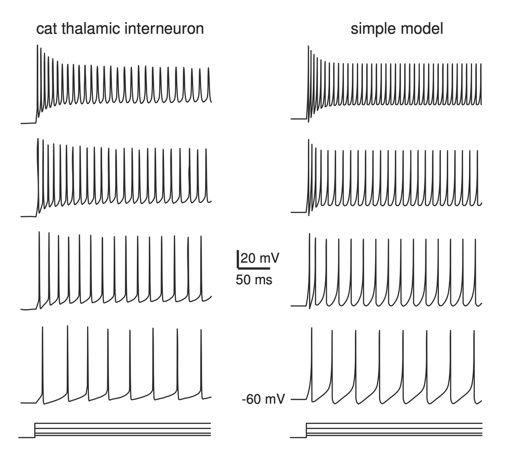

## Simple Model of the RTN

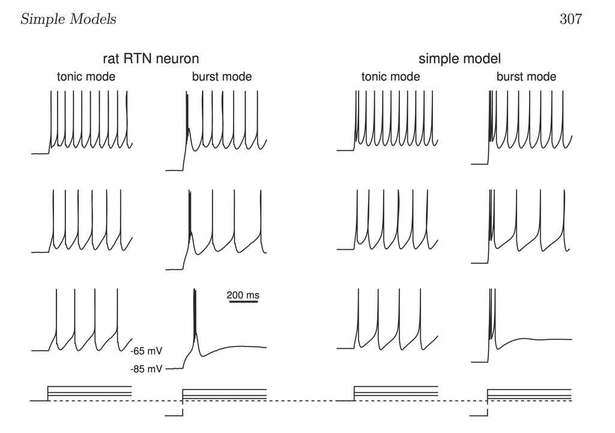

## Simple Model of the msn

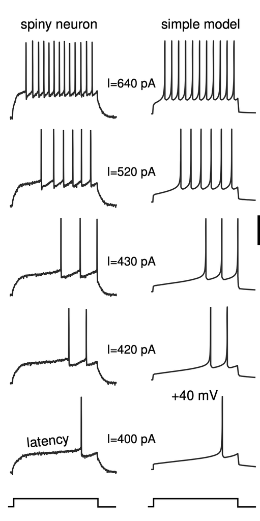